# 无题

[output not shown]

# R语言结课报告

班克坤

2022-06-08

## R语言实验作业

### 1.修改列名

```r
mt <- mtcars
colnames(mt)
names(mt)[1] <- "mileage"
# colnames(dataframe)  获得数据集的所有列名
# colnames[col-name] <- Var 通过访问列名-赋值的方式来修改列名
```

### 2.筛选数据

```r
mt[mt$cyl>4,]
# mt[行,列]通过数据实例名访问内容
# 使用 $ 访问数据集内部的数据
```

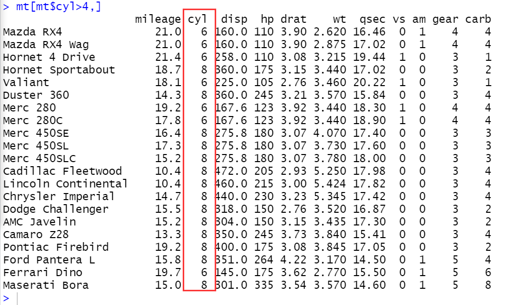

### 3.排序

```r
order(mt$mileage)
mt[order(mt$mileage),]
```

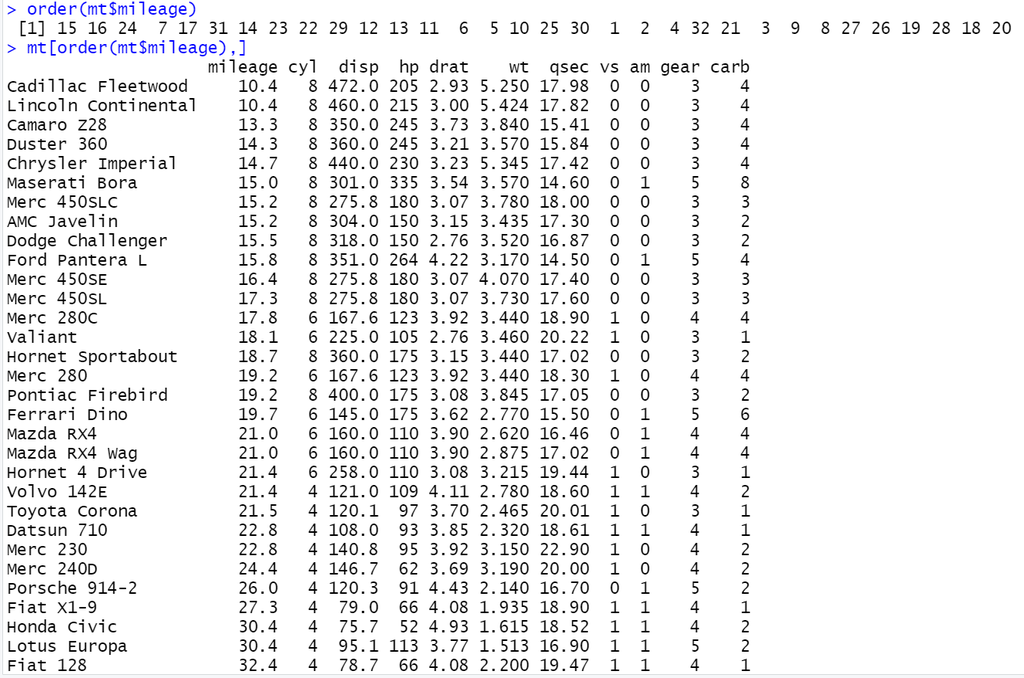

图2：实验结果

### 4.求和

```r
# 应用（数据集，1是操作行/2是操作列，fun为应用的函数）
apply(mtcars,2,sum)
# 求取mt的mileage列的和
```

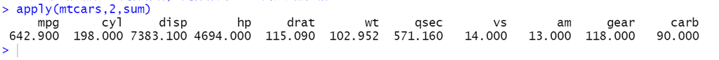

图3:实验结果

### 5.时间差

```r
#求取当前时间与1979.1.1的时差（星期计）
time_str <- "1900-06-02"
time_ticke <- as.Date(time_str)
# 强制将字符串转换成时间模式，要求字符串是时间形式
def_second <- difftime(Sys.Date(),time_ticke,units="weeks")
print(def_second)
# 计算时间差，units表示统计形式为weeks(统计周差，否则以秒计)
```

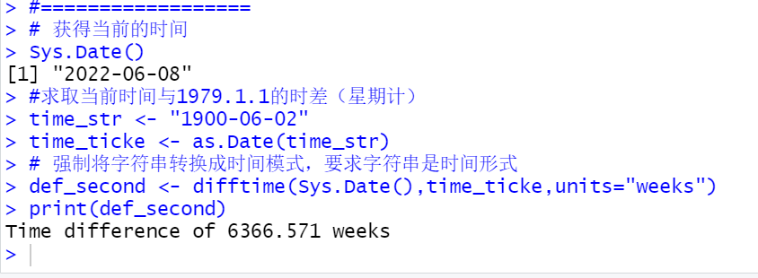

图4：实验结果

### 6.求导与画图

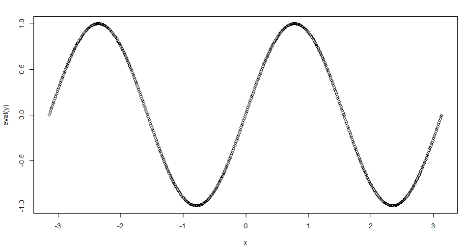

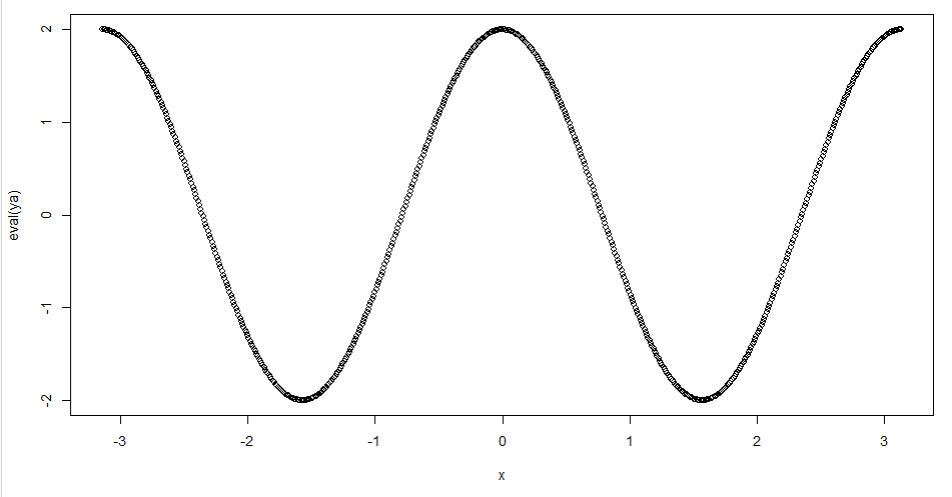

```r
# 准备求导
# 创建一个函数形式
y <- expression(sin(2*x))
x <- seq(-pi,pi,by=0.01)
eval(y)
plot(x,eval(y))
# 对X求导
ya <- D(y,'x')
# 绘制y'的函数曲线
plot(x,eval(ya))
```

### 7.画圆

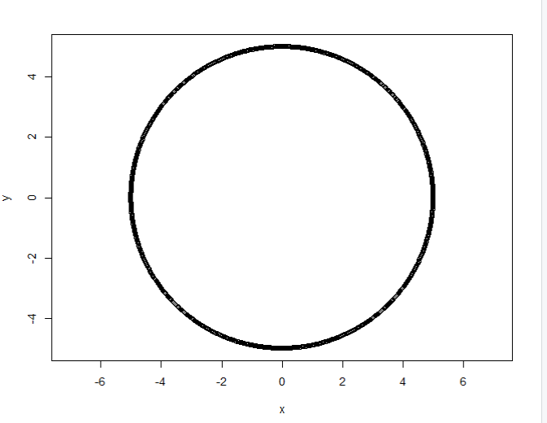

图6：实验结果

```r
# 定义一个函数
draw.circle<-function(R,xc,yc)
{ theta<-seq(0,2*pi,length.out=1000)
  x<-R*cos(theta)+xc
  y<-R*sin(theta)+yc
  plot(x,y,asp=1)
}
draw.circle(5,0,0)
# 画一个半径为5的○
```

### 8.字符串拼接

```r
# 字符合并
paste("Hello","NUIST")
```

这就不需要放结果了吧？？？

### 9.字符串循环输出

```r
for(i in 1:10) {
  print(paste("Hello","NUIST"))
}
```

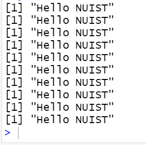

图7：实验结果

### 10.绘制散点图

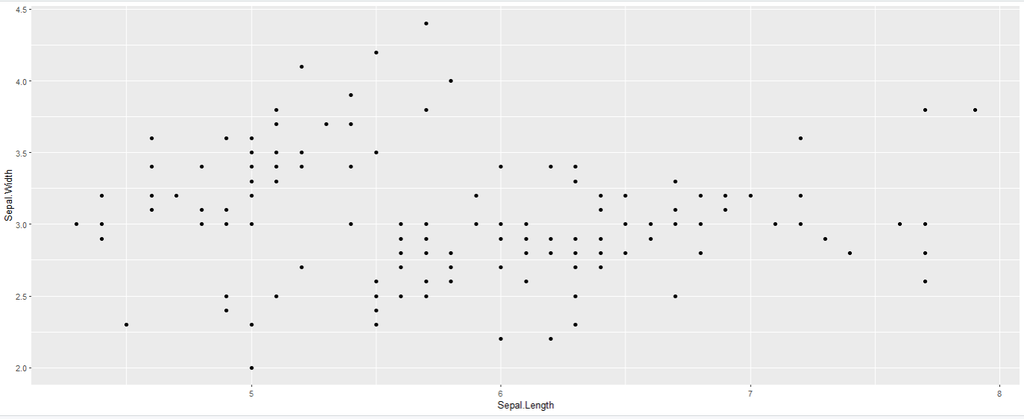

图8:实验结果

```r
# 引入包
library(ggplot2)
# 获取iris数据集
names(iris)
ggplot(iris,aes(x=Sepal.Length,
                y=Sepal.Width))+
  geom_point()
```

### 11.样本估计

```r
set.seed(111)
x.vector<-rnorm(1000,2,3)
maxl<-function(para,x)
{
  mu<-para[1]
  sigma<-para[2]
  res<-sum(dnorm(x,mu,sigma,log=T))
  return(-res)
}
optim(c(2,5),maxl,x=x.vector)
```

[figure not shown]

图9：实验结果

### 12.ANOVA分析

```r
PlantGrowth
aov.fit <- aov(weight~group,
               data=PlantGrowth)
summary(aov.fit)
```

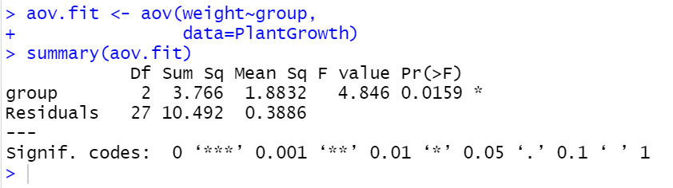

图10：实验结果

### 13.计算

计算积分
$$\int_{-1.96}^{1.96}\frac{1}{\sqrt{2\pi}}e^{-\frac{x^2}{2}dx}$$

```r
integrand<-function(x)
{exp(-x^2/2)/sqrt(2*pi)}
integrate(integrand,-1.96,1.96)
pnorm(1.96)-pnorm(-1.96)
```

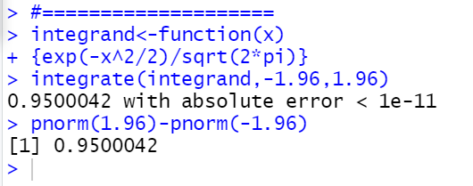

图11：实验结果

文章作者: QLozin

文章链接: https://loveloli.top/2022/06/09/R%E8%AF%AD%E8%A8%80%E4%BD%9C%E4%B8%9A/

[figure not shown]

[figure not shown]

[figure not shown]

[figure not shown]

[figure not shown]

[figure not shown]